# Choice Data ANOVA tables

Chandra Jack

December 11, 2017

## Preference Data: Constitutive defenses

The script used for this is the PrefPlastic17Nov2017.R file found in the src folder https://drive.google.com/open?id=14cdMdq77dwGCwBEXXVfOB7uV_1m1BdBV

The dataset is found in the constitutive data folder https://drive.google.com/open?id=1RRla12LJq7zppEN5uRPZvezYLPzLg251

I’ve uploaded the excel spreadsheet so that you can see the formulas that I used outside of R. You can convert that to a csv file if you want to follow from the beginning, otherwise use the uploaded modified csv file that starts at line 36.

Running a glm binomial model to check for preference for invasive or native range where 1 is invasive and 0 is native

```r
mod1 <- glm(as.factor(Inv_1_Nat_0) ~ Herbivore*CatStage , family = binomial(link = "logit"), data = PrefData)
anova(mod1, test = "Chisq")
```

```
## Analysis of Deviance Table
##
## Model: binomial, link: logit
##
## Response: as.factor(Inv_1_Nat_0)
##
## Terms added sequentially (first to last)
##
##
##                    Df Deviance Resid. Df Resid. Dev Pr(>Chi)
## NULL                                 137     182.84
## Herbivore           1   0.1235       136     182.72   0.7253
## CatStage            3   3.5845       133     179.14   0.3100
## Herbivore:CatStage  3   6.2443       130     172.89   0.1003
```

I realized that I never plotted this data.

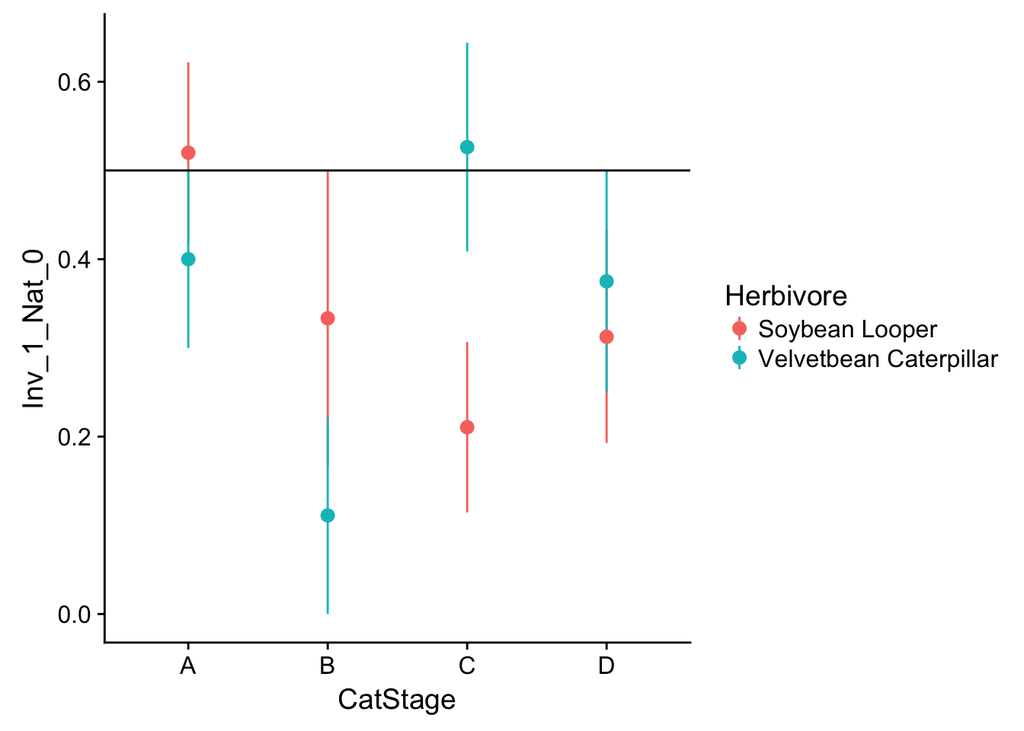

From this it looks as if there should be some type of significant difference, at least in the soybean looper data, but from the above ANOVA, it doesn’t show up. I am still concerned that there is a lack of replication but I subsetted the data and ran a non-parametric one sample t test (lines 43-48)

```r
PrefLoop <- subset(PrefData, Herbivore == "Soybean Looper")
PrefV <- subset(PrefData, Herbivore != "Soybean Looper")

# Looper data
wilcox.test(PrefLoop$Inv_1_Nat_0, mu = 0.5)
```

```
##
##  Wilcoxon signed rank test with continuity correction
##
## data:  PrefLoop$Inv_1_Nat_0
## V = 875, p-value = 0.02238
## alternative hypothesis: true location is not equal to 0.5
```

```r
# Velvet bean data
wilcox.test(PrefV$Inv_1_Nat_0, mu = 0.5)
```

```
##
##  Wilcoxon signed rank test with continuity correction
##
## data:  PrefV$Inv_1_Nat_0
## V = 945, p-value = 0.07149
## alternative hypothesis: true location is not equal to 0.5
```

Here is the ANOVA table based on the amount actually consumed and the non-p t test results.

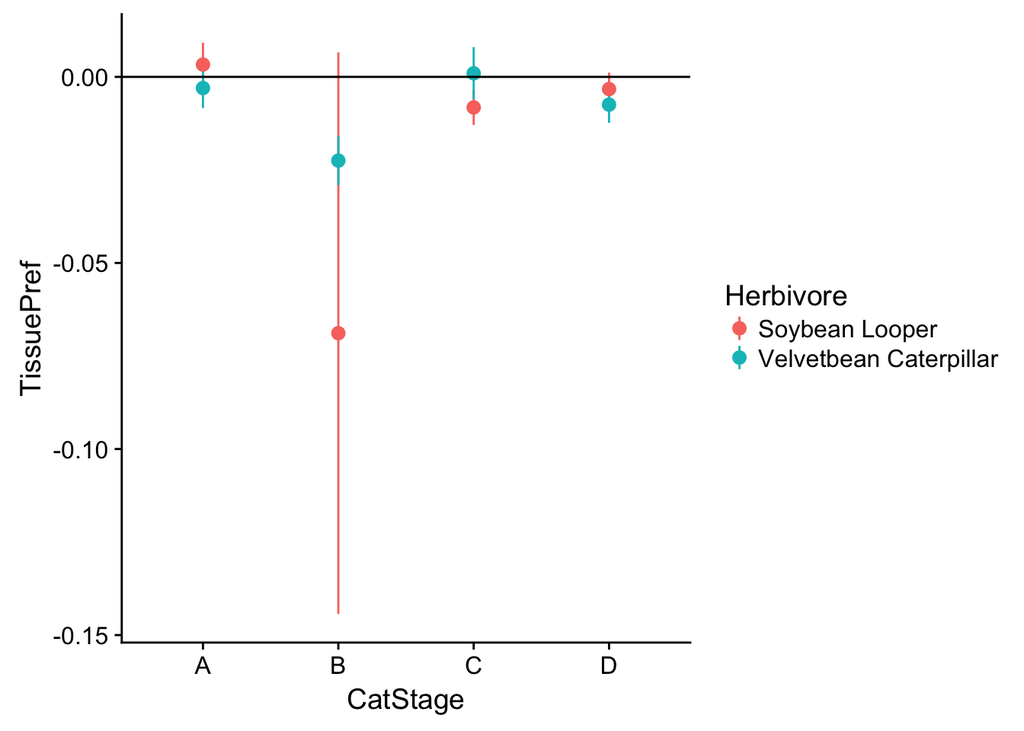

```r
mod3 <- lm(TissuePref ~ Herbivore*CatStage, data = PrefData)
anova(mod3)
```

```
## Analysis of Variance Table
##
## Response: TissuePref
##                     Df  Sum Sq   Mean Sq F value  Pr(>F)
## Herbivore            1 0.00098 0.0009755  0.2608 0.61045
## CatStage             3 0.02984 0.0099472  2.6592 0.05097 .
## Herbivore:CatStage   3 0.01014 0.0033798  0.9035 0.44142
## Residuals          130 0.48628 0.0037406
## ---
## Signif. codes:  0 '***' 0.001 '**' 0.01 '*' 0.05 '.' 0.1 ' ' 1
```

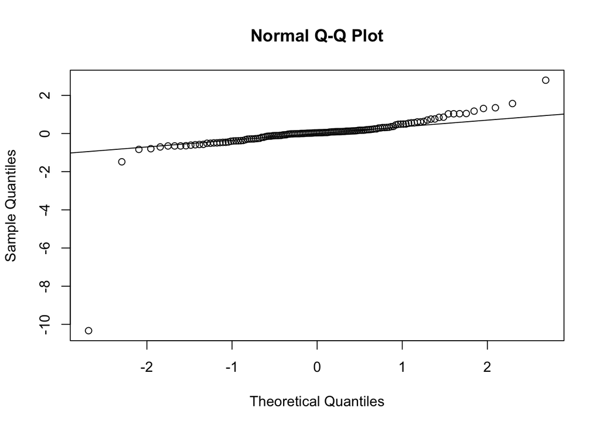

```r
M3.res <- rstandard(mod3)
qqnorm(M3.res)
qqline(M3.res)
```

```r
# Looper data
wilcox.test(PrefLoop$TissuePref, mu = 0)
```

```
##
##  Wilcoxon signed rank test with continuity correction
##
## data:  PrefLoop$TissuePref
## V = 964.5, p-value = 0.1471
## alternative hypothesis: true location is not equal to 0
```

```r
# Velvet bean data
wilcox.test(PrefV$TissuePref, mu = 0)
```

```
##
##  Wilcoxon signed rank test with continuity correction
##
## data:  PrefV$TissuePref
## V = 850.5, p-value = 0.03305
## alternative hypothesis: true location is not equal to 0
```

## Preference Data: Inducible/Plastic

This is included in the same script. The dataset is found in the inducible folder https://drive.google.com/open?id=1cY6FTjSg0KPTTiBgWsUsB8RI6H7Ezxm3

The excel spreadsheet is not in the folder just the csv file(s) I used. Use the Modified file to start at line 77.

```r
mod1 <- glm(as.factor(Con_1_Ind_0) ~ Herbivore*CatStage + Range, family = binomial(link = "logit"), data = PlasticData)
anova(mod1, test = "Chisq")
```

```
## Analysis of Deviance Table
##
## Model: binomial, link: logit
##
## Response: as.factor(Con_1_Ind_0)
##
## Terms added sequentially (first to last)
##
##
##                    Df Deviance Resid. Df Resid. Dev Pr(>Chi)
## NULL                                  79    106.819
## Herbivore           1   0.4746        78    106.344  0.49089
## CatStage            3   2.3676        75    103.977  0.49970
## Range               1   4.4731        74     99.503  0.03443 *
## Herbivore:CatStage  3   1.0858        71     98.418  0.78051
## ---
## Signif. codes:  0 '***' 0.001 '**' 0.01 '*' 0.05 '.' 0.1 ' ' 1
```

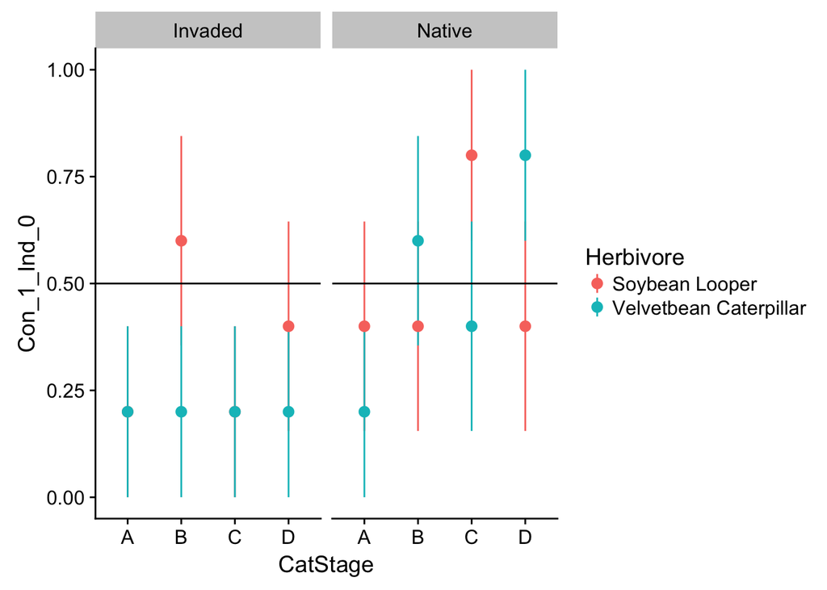

For completion, also included 2 group Mann-Whitney U

```r
# Looper
wilcox.test(PlasticLoop$Con_1_Ind_0 ~ PlasticLoop$Range)
```

```
##
##  Wilcoxon rank sum test with continuity correction
##
## data:  PlasticLoop$Con_1_Ind_0 by PlasticLoop$Range
## W = 170, p-value = 0.3515
## alternative hypothesis: true location shift is not equal to 0
```

```r
#Velvet bean
wilcox.test(PlasticV$Con_1_Ind_0 ~ PlasticV$Range)
```

```
##
##  Wilcoxon rank sum test with continuity correction
##
## data:  PlasticV$Con_1_Ind_0 by PlasticV$Range
## W = 140, p-value = 0.05146
## alternative hypothesis: true location shift is not equal to 0
```

Here is the data based on the amount of tissue consumed

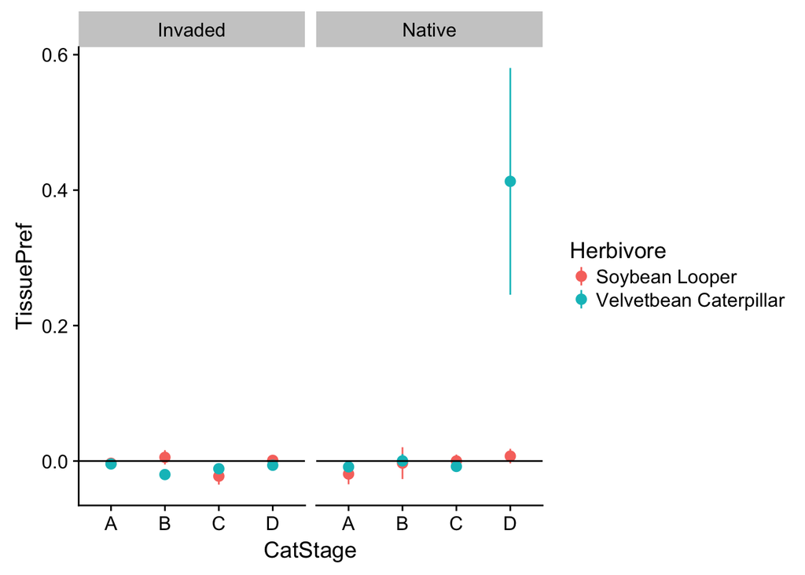

```r
mod4 <- lm(TissuePref ~ Herbivore*CatStage + Range, data = PlasticData)
anova(mod4)
```

```
## Analysis of Variance Table
##
## Response: TissuePref
##                    Df  Sum Sq  Mean Sq F value   Pr(>F)
## Herbivore           1 0.04723 0.047234  3.4407 0.067763 .
## CatStage            3 0.18726 0.062421  4.5469 0.005683 **
## Range               1 0.06123 0.061234  4.4604 0.038209 *
## Herbivore:CatStage  3 0.15196 0.050655  3.6898 0.015756 *
## Residuals          71 0.97471 0.013728
## ---
## Signif. codes:  0 '***' 0.001 '**' 0.01 '*' 0.05 '.' 0.1 ' ' 1
```

```r
# Looper
wilcox.test(PlasticLoop$TissuePref ~ PlasticLoop$Range)
```

```
##
##  Wilcoxon rank sum test with continuity correction
##
## data:  PlasticLoop$TissuePref by PlasticLoop$Range
## W = 189.5, p-value = 0.7868
## alternative hypothesis: true location shift is not equal to 0
```

```r
#Velvet bean
wilcox.test(PlasticV$TissuePref ~ PlasticV$Range)
```

```
##
##  Wilcoxon rank sum test
##
## data:  PlasticV$TissuePref by PlasticV$Range
## W = 148, p-value = 0.1653
## alternative hypothesis: true location shift is not equal to 0
```